# import package

```python
# import package
# warning
import warnings
warnings.filterwarnings("ignore")
# data
import numpy as np
import pandas as pd
# visulaize
import matplotlib.pyplot as plt
from matplotlib.ticker import PercentFormatter
# adjust data
from sklearn.model_selection import train_test_split
from sklearn.preprocessing import StandardScaler
# ML
from sklearn.linear_model import LogisticRegression
from sklearn.svm import SVC, LinearSVC
from sklearn.neural_network import MLPClassifier
from keras.models import Sequential
from keras.layers import Dense, Dropout
from keras.optimizers import Adam
from sklearn.model_selection import GridSearchCV
# PCA
from sklearn.decomposition import PCA
# evaluate
from sklearn.metrics import accuracy_score, precision_score, recall_score, confusion_matrix, f1_score, classification_report, ConfusionMatrixDisplay
```

# import function

```python
# import ML_func.py
from ML_func import ml_func
func = ml_func()
```

# import data

```python
att_data = pd.read_csv("face_data.csv")
att_data.head()
```

|  | 0 | 1 | 2 | 3 | 4 | 5 | 6 | 7 | 8 | 9 | ... | 4087 | 4088 | 4089 | 4090 | 4091 | 4092 | 4093 | 4094 | 4095 | target |
| --- | --- | --- | --- | --- | --- | --- | --- | --- | --- | --- | --- | --- | --- | --- | --- | --- | --- | --- | --- | --- | --- |
| 0 | 0.309917 | 0.367769 | 0.417355 | 0.442149 | 0.528926 | 0.607438 | 0.657025 | 0.677686 | 0.690083 | 0.685950 | ... | 0.669422 | 0.652893 | 0.661157 | 0.475207 | 0.132231 | 0.148760 | 0.152893 | 0.161157 | 0.157025 | 0 |
| 1 | 0.454545 | 0.471074 | 0.512397 | 0.557851 | 0.595041 | 0.640496 | 0.681818 | 0.702479 | 0.710744 | 0.702479 | ... | 0.157025 | 0.136364 | 0.148760 | 0.152893 | 0.152893 | 0.152893 | 0.152893 | 0.152893 | 0.152893 | 0 |
| 2 | 0.318182 | 0.400826 | 0.491736 | 0.528926 | 0.586777 | 0.657025 | 0.681818 | 0.685950 | 0.702479 | 0.698347 | ... | 0.132231 | 0.181818 | 0.136364 | 0.128099 | 0.148760 | 0.144628 | 0.140496 | 0.148760 | 0.152893 | 0 |
| 3 | 0.198347 | 0.194215 | 0.194215 | 0.194215 | 0.190083 | 0.190083 | 0.243802 | 0.404959 | 0.483471 | 0.516529 | ... | 0.636364 | 0.657025 | 0.685950 | 0.727273 | 0.743802 | 0.764463 | 0.752066 | 0.752066 | 0.739669 | 0 |
| 4 | 0.500000 | 0.545455 | 0.582645 | 0.623967 | 0.648760 | 0.690083 | 0.694215 | 0.714876 | 0.723140 | 0.731405 | ... | 0.161157 | 0.177686 | 0.173554 | 0.177686 | 0.177686 | 0.177686 | 0.177686 | 0.173554 | 0.173554 | 0 |

5 rows × 4097 columns

# process data

```python
# take out X, y
X = att_data.drop(columns=['target'])
y = att_data['target']
```

## original data

```python
X_train_original, X_test_original, y_train, y_test = func.preprocess_data(
    X, y, 65536)
```

```
training data : 320
testing data : 80
```

## standardize data

```python
X_train_scaled, X_test_scaled, y_train, y_test = func.preprocess_data(
    X, y, 65536, standard="True")
```

```
standardlize training data : 320
standardlize testing data : 80
```

## pca data

```
standardlize training data : 320
standardlize testing data : 80
finish doing pca
```

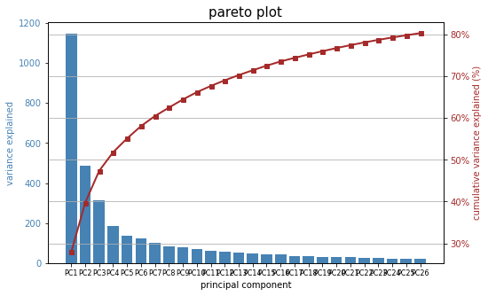

```python
X_train_pca, X_test_pca, y_train, y_test = func.preprocess_data(
    X, y, 65536, standard="True", pca="True", n_pc=0.8, show_plot="True")
```

上述得到的檔案共有 3 個，分別是以下 :

- 原始的資料 (original)
- 標準化後的資料 (scaled)
- 先標準化過後，再進行 PCA 的資料，取累積解釋力到 0.8 的 (pca)

之後藉由這些資料各自拆分成不同的 train & test  
共得到 3 種類型的資料

# modeling standardize data

把標準化後的資料建模

## MLR

多元羅吉斯回歸 (Multinomial Logistic Regression)  
建模之後以 測試集 進行評估  
並且列出 4 種指標以供觀察

### default

```python
# MLR model & hyperparametersmodel
mlr_opts = dict(multi_class='auto', tol=1e-6, max_iter=int(1e6), verbose=1)
mlr_model = LogisticRegression(**mlr_opts)
mlr_model.fit(X_train_scaled, y_train)
# predict
y_pred_mlr = mlr_model.predict(X_test_scaled)
```

```python
# evaluation
mlr_eva = func.evaluate_model(y_test, y_pred_mlr)
# change to df
mlr_df = pd.DataFrame(list(mlr_eva.items()), columns=[
                      ["standard", "standard"], ["MLR", "MLR"], ['metric', 'value']])
mlr_df
```

|  | standard MLR metric | standard MLR value |
| --- | --- | --- |
| 0 | accuracy | 0.99 |
| 1 | precision | 0.99 |
| 2 | recall | 0.99 |
| 3 | F1-score | 0.99 |

### grid search

```python
# search best parameter
param_grid = {
    'C': [0.01, 0.1, 1],
    'solver': ['newton-cg', 'lbfgs'],
    'penalty': ['l1', 'l2']
}

# model
mlr_opts = dict(multi_class='auto', tol=1e-6, max_iter=int(1e6), verbose=1)
mlr_model = LogisticRegression(**mlr_opts)

# grid search
grid_search = GridSearchCV(mlr_model, param_grid, cv=5, verbose=2, n_jobs=-1)
grid_search.fit(X_train_scaled, y_train)

# print
print("Best parameters found: ", grid_search.best_params_)

# predict
best_model = grid_search.best_estimator_
y_pred_mlr_best = best_model.predict(X_test_scaled)
```

```
Fitting 5 folds for each of 12 candidates, totalling 60 fits
Best parameters found:  {'C': 1, 'penalty': 'l2', 'solver': 'newton-cg'}
```

```python
# evaluation
mlr_eva_best = func.evaluate_model(y_test, y_pred_mlr_best)
# change to df
mlr_df_best = pd.DataFrame(list(mlr_eva_best.items()), columns=[
                      ["standard", "standard"], ["MLR", "MLR"], ['metric', 'value']])
mlr_df_best
```

|  | standard MLR metric | standard MLR value |
| --- | --- | --- |
| 0 | accuracy | 0.99 |
| 1 | precision | 0.99 |
| 2 | recall | 0.99 |
| 3 | F1-score | 0.99 |

### MLR conclusion

可以發現 2個的結果相同  
為了避免麻煩  
因此使用 default 為最佳模型

## SVM

支援向量機 (Support Vector Machine)  
建模之後以 測試集 進行評估  
並且列出 4 種指標以供觀察

### default

```python
# SVM model & hyperparameter
svm_opts = dict(C=1, tol=1e-6, max_iter=int(1e6))
svm_model = SVC(kernel='linear', **svm_opts)
svm_model.fit(X_train_scaled, y_train)
# predict
y_pred_svm = svm_model.predict(X_test_scaled)
```

```python
# evaluation
svm_eva = func.evaluate_model(y_test, y_pred_svm)
# change to df
svm_df = pd.DataFrame(list(svm_eva.items()), columns=[
                      ["standard", "standard"], ["SVM", "SVM"], ['metric', 'value']])
svm_df
```

|  | standard SVM metric | standard SVM value |
| --- | --- | --- |
| 0 | accuracy | 0.99 |
| 1 | precision | 0.99 |
| 2 | recall | 0.99 |
| 3 | F1-score | 0.99 |

### grid search

```python
# search best parameter
param_grid = {
    'C': [0.08, 0.1, 1, 5],
    'kernel': ['linear', 'poly', 'rbf', 'sigmoid'],
    'gamma': ['scale', 'auto'],
}

# model
svm_opts = dict(tol=1e-6, max_iter=int(1e6))
svm_model = SVC(**svm_opts)

# grid search
grid_search = GridSearchCV(svm_model, param_grid, cv=5, verbose=2, n_jobs=-1)
grid_search.fit(X_train_scaled, y_train)

# print
print("Best parameters found: ", grid_search.best_params_)

# predict
best_model = grid_search.best_estimator_
y_pred_svm_best = best_model.predict(X_test_scaled)
```

```
Fitting 5 folds for each of 32 candidates, totalling 160 fits
Best parameters found:  {'C': 0.08, 'gamma': 'scale', 'kernel': 'linear'}
```

```python
# evaluation
svm_eva_best = func.evaluate_model(y_test, y_pred_svm_best)
# change to df
svm_df_best = pd.DataFrame(list(svm_eva_best.items()), columns=[
                      ["standard", "standard"], ["SVM", "SVM"], ['metric', 'value']])
svm_df_best
```

|  | standard SVM metric | standard SVM value |
| --- | --- | --- |
| 0 | accuracy | 0.96 |
| 1 | precision | 0.98 |
| 2 | recall | 0.96 |
| 3 | F1-score | 0.97 |

## NN--MLP

神經網路 (Neural Network) -- 多層感知機 (Multilayer perceptron)  
建模之後以 測試集 進行評估  
並且列出 4 種指標以供觀察

### default

```python
# NN-MLP model & hyperparameter
hidden_layers = (30,)
opts = dict(hidden_layer_sizes=hidden_layers, verbose=0,
            activation='relu', tol=1e-6, max_iter=int(1e6))
nn_mlp_model = MLPClassifier(solver='adam', **opts)
nn_mlp_model.fit(X_train_scaled, y_train)
# predict
y_pred_nn_mlp = nn_mlp_model.predict(X_test_scaled)
```

```python
# evaluation
nn_mlp_eva = func.evaluate_model(y_test, y_pred_nn_mlp)
# change to df
nn_mlp_df = pd.DataFrame(list(nn_mlp_eva.items()), columns=[
                         ["standard", "standard"], ["NN_MLP", "NN_MLP"], ['metric', 'value']])
nn_mlp_df
```

|  | standard NN_MLP metric | standard NN_MLP value |
| --- | --- | --- |
| 0 | accuracy | 0.89 |
| 1 | precision | 0.94 |
| 2 | recall | 0.89 |
| 3 | F1-score | 0.89 |

### grid search

```python
# search best parameter
param_grid = {
    'hidden_layer_sizes': [(30,)],
    'activation': ['logistic', 'relu'],
    'solver': ['lbfgs', 'sgd', 'adam'],
}

# model
opts = dict(verbose=1, tol=1e-6, max_iter=int(1e6))
nn_mlp_model = MLPClassifier(**opts)

# grid search
grid_search = GridSearchCV(nn_mlp_model, param_grid, cv=5, verbose=2, n_jobs=-1)
grid_search.fit(X_train_scaled, y_train)

# print
print("Best parameters found: ", grid_search.best_params_)

# predict
best_model = grid_search.best_estimator_
y_pred_nn_mlp_best = best_model.predict(X_test_scaled)
# running time : 37m 43s
# Iteration 23580, loss = 0.02097050
# Training loss did not improve more than tol=0.000001 for 10 consecutive epochs. Stopping.
# Best parameters found:  {'activation': 'logistic', 'hidden_layer_sizes': (30,), 'solver': 'sgd'}
```

[output not shown]

[output cut: 23528 more lines]

[output not shown]

```python
# evaluation
nn_mlp_eva_best = func.evaluate_model(y_test, y_pred_nn_mlp_best)
# change to df
nn_mlp_df_best = pd.DataFrame(list(nn_mlp_eva_best.items()), columns=[
                         ["standard", "standard"], ["NN_MLP", "NN_MLP"], ['metric', 'value']])
nn_mlp_df_best
```

|  | standard NN_MLP metric | standard NN_MLP value |
| --- | --- | --- |
| 0 | accuracy | 0.95 |
| 1 | precision | 0.97 |
| 2 | recall | 0.95 |
| 3 | F1-score | 0.95 |

### NN--MLP conclusion

可以發現 best 的結果就已經是最好的  
因此使用 best 為最佳模型

## NN--SEQ

神經網路 (Neural Network) -- 簡單的線性堆疊模型  
一層一層的建立神經網路  
接著列出現在構建的網路長甚麼樣子  
建模之後以 測試集 進行評估  
並且列出 4 種指標以供觀察

```python
# change 1~3 to 0~2
y_train_nn = y_train
y_test_nn = y_test

# model
nn_seq_model = Sequential()
nn_seq_model.add(Dense(64, activation='relu',
                 input_shape=(X_train_scaled.shape[1],)))
nn_seq_model.add(Dense(32, activation='relu'))
# avoid overfitting
nn_seq_model.add(Dropout(0.2))
nn_seq_model.add(Dense(40, activation='softmax'))

# compile
# set learning rate
optimizer = Adam(learning_rate=0.001)
nn_seq_model.compile(optimizer=optimizer,
                     loss='sparse_categorical_crossentropy',
                     metrics=['accuracy'])

# check model
nn_seq_model.summary()
```

```
WARNING:tensorflow:From C:\Users\ACER\anaconda3\lib\site-packages\keras\src\backend.py:873: The name tf.get_default_graph is deprecated. Please use tf.compat.v1.get_default_graph instead.

Model: "sequential"
_________________________________________________________________
 Layer (type)                Output Shape              Param #
=================================================================
 dense (Dense)               (None, 64)                262208

 dense_1 (Dense)             (None, 32)                2080

 dropout (Dropout)           (None, 32)                0

 dense_2 (Dense)             (None, 40)                1320

=================================================================
Total params: 265608 (1.01 MB)
Trainable params: 265608 (1.01 MB)
Non-trainable params: 0 (0.00 Byte)
_________________________________________________________________
```

```python
# fit model
history = nn_seq_model.fit(X_train_scaled, y_train_nn,
                           epochs=50, validation_split=0.2, verbose=0)
```

[output not shown]

```python
# evaluation
test_loss, test_accuracy = nn_seq_model.evaluate(
    X_test_scaled, y_test_nn, verbose=0)
y_pred_prob = nn_seq_model.predict(X_test_scaled, verbose=0)
y_pred_nn_seq = np.argmax(y_pred_prob, axis=1)
print("loss :", test_loss)
print("accuracy :", test_accuracy)
```

```
loss : 0.2628282904624939
accuracy : 0.9125000238418579
```

```python
# evaluation
nn_seq_eva = func.evaluate_model(y_test_nn, y_pred_nn_seq)
# change to df
nn_seq_df = pd.DataFrame(list(nn_seq_eva.items()), columns=[
                         ["standard", "standard"], ["NN_SEQ", "NN_SEQ"], ['metric', 'value']])
nn_seq_df
```

|  | standard NN_SEQ metric | standard NN_SEQ value |
| --- | --- | --- |
| 0 | accuracy | 0.91 |
| 1 | precision | 0.94 |
| 2 | recall | 0.91 |
| 3 | F1-score | 0.91 |

## compare evaluation of standardize data

把上述所有的評估指標組合一起觀察

```python
# combine df together
mlr_df_copy = mlr_df.copy()
svm_df_copy = svm_df.copy()
nn_mlp_df_best_copy = nn_mlp_df_best.copy()
nn_seq_df_copy = nn_seq_df.copy()
# del same col
svm_df_copy.drop(("standard", "SVM", "metric"), axis=1, inplace=True)
nn_mlp_df_best_copy.drop(("standard", "NN_MLP", "metric"), axis=1, inplace=True)
nn_seq_df_copy.drop(("standard", "NN_SEQ", "metric"), axis=1, inplace=True)

# combine
final_df_standard = pd.concat(
    [mlr_df_copy, svm_df_copy, nn_mlp_df_best_copy, nn_seq_df_copy], axis=1)
# set "metric" to index
final_df_standard.set_index(("standard", "MLR", "metric"), inplace=True)
final_df_standard = final_df_standard.rename_axis("metric")

# show
final_df_standard
```

| metric | standard MLR value | standard SVM value | standard NN_MLP value | standard NN_SEQ value |
| --- | --- | --- | --- | --- |
| accuracy | 0.99 | 0.99 | 0.95 | 0.91 |
| precision | 0.99 | 0.99 | 0.97 | 0.94 |
| recall | 0.99 | 0.99 | 0.95 | 0.91 |
| F1-score | 0.99 | 0.99 | 0.95 | 0.91 |

# modeling pca data

把 PCA 後的資料建模

## MLR

多元羅吉斯回歸 (Multinomial Logistic Regression)  
建模之後以 測試集 進行評估  
並且列出 4 種指標以供觀察

### default

```python
# MLR model & hyperparametersmodel
mlr_opts = dict(multi_class='auto', tol=1e-6, max_iter=int(1e6), verbose=1)
mlr_model = LogisticRegression(**mlr_opts)
mlr_model.fit(X_train_pca, y_train)
# predict
y_pred_mlr = mlr_model.predict(X_test_pca)
```

```python
# evaluation
mlr_eva = func.evaluate_model(y_test, y_pred_mlr)
# change to df
mlr_df = pd.DataFrame(list(mlr_eva.items()), columns=[
                      ["PCA", "PCA"], ["MLR", "MLR"], ['metric', 'value']])
mlr_df
```

|  | PCA MLR metric | PCA MLR value |
| --- | --- | --- |
| 0 | accuracy | 0.99 |
| 1 | precision | 0.99 |
| 2 | recall | 0.99 |
| 3 | F1-score | 0.99 |

### grid search

```python
# search best parameter
param_grid = {
    'C': [0.01, 0.1, 1],
    'solver': ['newton-cg', 'lbfgs'],
    'penalty': ['l1', 'l2']
}

# model
mlr_opts = dict(multi_class='auto', tol=1e-6, max_iter=int(1e6), verbose=1)
mlr_model = LogisticRegression(**mlr_opts)

# grid search
grid_search = GridSearchCV(mlr_model, param_grid, cv=5, verbose=2, n_jobs=-1)
grid_search.fit(X_train_pca, y_train)

# print
print("Best parameters found: ", grid_search.best_params_)

# predict
best_model = grid_search.best_estimator_
y_pred_mlr_best = best_model.predict(X_test_pca)
```

```
Fitting 5 folds for each of 12 candidates, totalling 60 fits
Best parameters found:  {'C': 1, 'penalty': 'l2', 'solver': 'newton-cg'}
```

```python
# evaluation
mlr_eva_best = func.evaluate_model(y_test, y_pred_mlr_best)
# change to df
mlr_df_best = pd.DataFrame(list(mlr_eva_best.items()), columns=[
                      ["PCA", "PCA"], ["MLR", "MLR"], ['metric', 'value']])
mlr_df_best
```

|  | PCA MLR metric | PCA MLR value |
| --- | --- | --- |
| 0 | accuracy | 0.99 |
| 1 | precision | 0.99 |
| 2 | recall | 0.99 |
| 3 | F1-score | 0.99 |

### MLR conclusion

可以發現 2個的結果相同  
為了避免麻煩  
因此使用 default 為最佳模型

## SVM

支援向量機 (Support Vector Machine)  
建模之後以 測試集 進行評估  
並且列出 4 種指標以供觀察

### default

```python
# SVM model & hyperparameter
svm_opts = dict(C=1, tol=1e-6, max_iter=int(1e6))
svm_model = SVC(kernel='linear', **svm_opts)
svm_model.fit(X_train_pca, y_train)
# predict
y_pred_svm = svm_model.predict(X_test_pca)
```

```python
# evaluation
svm_eva = func.evaluate_model(y_test, y_pred_svm)
# change to df
svm_df = pd.DataFrame(list(svm_eva.items()), columns=[
                      ["PCA", "PCA"], ["SVM", "SVM"], ['metric', 'value']])
svm_df
```

|  | PCA SVM metric | PCA SVM value |
| --- | --- | --- |
| 0 | accuracy | 0.99 |
| 1 | precision | 0.99 |
| 2 | recall | 0.99 |
| 3 | F1-score | 0.99 |

### grid search

```python
# search best parameter
param_grid = {
    'C': [0.08, 0.1, 1, 5],
    'kernel': ['linear', 'poly', 'rbf', 'sigmoid'],
    'gamma': ['scale', 'auto'],
}

# model
svm_opts = dict(tol=1e-6, max_iter=int(1e6))
svm_model = SVC(**svm_opts)

# grid search
grid_search = GridSearchCV(svm_model, param_grid, cv=5, verbose=2, n_jobs=-1)
grid_search.fit(X_train_pca, y_train)

# print
print("Best parameters found: ", grid_search.best_params_)

# predict
best_model = grid_search.best_estimator_
y_pred_svm_best = best_model.predict(X_test_pca)
```

```
Fitting 5 folds for each of 32 candidates, totalling 160 fits
Best parameters found:  {'C': 0.08, 'gamma': 'scale', 'kernel': 'linear'}
```

```python
# evaluation
svm_eva_best = func.evaluate_model(y_test, y_pred_svm_best)
# change to df
svm_df_best = pd.DataFrame(list(svm_eva_best.items()), columns=[
                      ["PCA", "PCA"], ["SVM", "SVM"], ['metric', 'value']])
svm_df_best
```

|  | PCA SVM metric | PCA SVM value |
| --- | --- | --- |
| 0 | accuracy | 0.99 |
| 1 | precision | 0.99 |
| 2 | recall | 0.99 |
| 3 | F1-score | 0.99 |

### SVM conclusion

可以發現 2個的結果相同  
為了避免麻煩  
因此使用 default 為最佳模型

## NN--MLP

神經網路 (Neural Network) -- 多層感知機 (Multilayer perceptron)  
建模之後以 測試集 進行評估  
並且列出 4 種指標以供觀察

### default

```python
# NN-MLP model & hyperparameter
hidden_layers = (30,)
opts = dict(hidden_layer_sizes=hidden_layers, verbose=0,
            activation='relu', tol=1e-6, max_iter=int(1e6))
nn_mlp_model = MLPClassifier(solver='adam', **opts)
nn_mlp_model.fit(X_train_pca, y_train)
# predict
y_pred_nn_mlp = nn_mlp_model.predict(X_test_pca)
```

```python
# evaluation
nn_mlp_eva = func.evaluate_model(y_test, y_pred_nn_mlp)
# change to df
nn_mlp_df = pd.DataFrame(list(nn_mlp_eva.items()), columns=[
                         ["PCA", "PCA"], ["NN_MLP", "NN_MLP"], ['metric', 'value']])
nn_mlp_df
```

[output not shown]

### grid search

```python
# search best parameter
param_grid = {
    'hidden_layer_sizes': [(30,)],
    'activation': ['logistic', 'tanh', 'relu'],
    'solver': ['lbfgs', 'sgd', 'adam'],
}

# model
opts = dict(verbose=1, tol=1e-6, max_iter=int(1e6))
nn_mlp_model = MLPClassifier(**opts)

# grid search
grid_search = GridSearchCV(nn_mlp_model, param_grid, cv=5, verbose=2, n_jobs=-1)
grid_search.fit(X_train_pca, y_train)

# print
print("Best parameters found: ", grid_search.best_params_)

# predict
best_model = grid_search.best_estimator_
y_pred_nn_mlp_best = best_model.predict(X_test_pca)
```

```
Fitting 5 folds for each of 9 candidates, totalling 45 fits
Best parameters found:  {'activation': 'relu', 'hidden_layer_sizes': (30,), 'solver': 'lbfgs'}
```

```python
# evaluation
nn_mlp_eva_best = func.evaluate_model(y_test, y_pred_nn_mlp_best)
# change to df
nn_mlp_df_best = pd.DataFrame(list(nn_mlp_eva_best.items()), columns=[
                         ["PCA", "PCA"], ["NN_MLP", "NN_MLP"], ['metric', 'value']])
nn_mlp_df_best
```

|  | PCA NN_MLP metric | PCA NN_MLP value |
| --- | --- | --- |
| 0 | accuracy | 0.95 |
| 1 | precision | 0.97 |
| 2 | recall | 0.95 |
| 3 | F1-score | 0.95 |

### NN--MLP conclusion

可以發現 best 的結果就已經是最好的  
因此使用 best 為最佳模型

## NN--SEQ

```python
# change 1~3 to 0~2
y_train_nn = y_train
y_test_nn = y_test

# model
nn_seq_model = Sequential()
nn_seq_model.add(Dense(64, activation='relu',
                 input_shape=(X_train_pca.shape[1],)))
nn_seq_model.add(Dense(32, activation='relu'))
# avoid overfitting
nn_seq_model.add(Dropout(0.2))
nn_seq_model.add(Dense(40, activation='softmax'))

# compile
# set learning rate
optimizer = Adam(learning_rate=0.001)
nn_seq_model.compile(optimizer=optimizer,
                     loss='sparse_categorical_crossentropy',
                     metrics=['accuracy'])

# check model
nn_seq_model.summary()
```

```
Model: "sequential_2"
_________________________________________________________________
 Layer (type)                Output Shape              Param #
=================================================================
 dense_6 (Dense)             (None, 64)                1728

 dense_7 (Dense)             (None, 32)                2080

 dropout_2 (Dropout)         (None, 32)                0

 dense_8 (Dense)             (None, 40)                1320

=================================================================
Total params: 5128 (20.03 KB)
Trainable params: 5128 (20.03 KB)
Non-trainable params: 0 (0.00 Byte)
_________________________________________________________________
```

```python
# fit model
history = nn_seq_model.fit(X_train_pca, y_train_nn,
                           epochs=200, validation_split=0.2, verbose=1)
```

[output not shown]

```python
# evaluation
test_loss, test_accuracy = nn_seq_model.evaluate(
    X_test_pca, y_test_nn, verbose=0)
y_pred_prob = nn_seq_model.predict(X_test_pca, verbose=0)
y_pred_nn_seq = np.argmax(y_pred_prob, axis=1)
print("loss :", test_loss)
print("accuracy :", test_accuracy)
```

```
loss : 0.2821381986141205
accuracy : 0.9125000238418579
```

```python
# evaluation
nn_seq_eva = func.evaluate_model(y_test_nn, y_pred_nn_seq)
# change to df
nn_seq_df = pd.DataFrame(list(nn_seq_eva.items()), columns=[
                         ["PCA", "PCA"], ["NN_SEQ", "NN_SEQ"], ['metric', 'value']])
nn_seq_df
```

|  | PCA NN_SEQ metric | PCA NN_SEQ value |
| --- | --- | --- |
| 0 | accuracy | 0.91 |
| 1 | precision | 0.94 |
| 2 | recall | 0.91 |
| 3 | F1-score | 0.91 |

## compare evaluation of pca data

```python
# combine df together
mlr_df_copy = mlr_df.copy()
svm_df_copy = svm_df.copy()
nn_mlp_df_best_copy = nn_mlp_df_best.copy()
nn_seq_df_copy = nn_seq_df.copy()
# del same col
svm_df_copy.drop(("PCA", "SVM", "metric"), axis=1, inplace=True)
nn_mlp_df_best_copy.drop(("PCA", "NN_MLP", "metric"), axis=1, inplace=True)
nn_seq_df_copy.drop(("PCA", "NN_SEQ", "metric"), axis=1, inplace=True)

# combine
final_df_pca = pd.concat(
    [mlr_df_copy, svm_df_copy, nn_mlp_df_best_copy, nn_seq_df_copy], axis=1)
# set "metric" to index
final_df_pca.set_index(("PCA", "MLR", "metric"), inplace=True)
final_df_pca = final_df.rename_axis("metric")

# show
final_df_pca
```

| metric | PCA MLR value | PCA SVM value | PCA NN_MLP value | PCA NN_SEQ value |
| --- | --- | --- | --- | --- |
| accuracy | 0.99 | 0.99 | 0.95 | 0.91 |
| precision | 0.99 | 0.99 | 0.97 | 0.94 |
| recall | 0.99 | 0.99 | 0.95 | 0.91 |
| F1-score | 0.99 | 0.99 | 0.95 | 0.91 |

## model of pca data conclusion

可以看出總體來說 MLR、SVM 模型的表現是最好的  
這 2 者相較於神經網路  
不僅可以得到非常高的評估指標分數  
同時運行時間也比較短

# final conclusion

把上述所有的評估指標組合一起觀察

```python
# final conclusion
final_df = pd.concat(
    [final_df_standard, final_df_pca], axis=1)
final_df
```

| metric | standard MLR value | standard SVM value | standard NN_MLP value | standard NN_SEQ value | PCA MLR value | PCA SVM value | PCA NN_MLP value | PCA NN_SEQ value |
| --- | --- | --- | --- | --- | --- | --- | --- | --- |
| accuracy | 0.99 | 0.99 | 0.95 | 0.91 | 0.99 | 0.99 | 0.95 | 0.91 |
| precision | 0.99 | 0.99 | 0.97 | 0.94 | 0.99 | 0.99 | 0.97 | 0.94 |
| recall | 0.99 | 0.99 | 0.95 | 0.91 | 0.99 | 0.99 | 0.95 | 0.91 |
| F1-score | 0.99 | 0.99 | 0.95 | 0.91 | 0.99 | 0.99 | 0.95 | 0.91 |

可以發現到其實資料集進行標準化與加上 PCA 之後並沒有很大的差別  
猜測有可能是因為資料集不夠大所以造成沒有太大的差異  
另外也只需要用到比較基礎的模型就能夠得到還不錯的效果